# Mixed Models per dati EEG

Applicazione della metodologia lmeEEG

Enrico Bettiol, Nicola Castelletti, Francesca Remigio, Andrea Simonetto

2024-06-29

# 1 Introduzione

## 1.1 I dati EEG

Le neuroscienze cognitive sono un insieme di discipline che studiano gli effetti strutturali e funzionali del cervello, con lo scopo di chiarire una possibile relazione tra l’attività cognitiva e un determinato funzionamento cerebrale.

Alla base di queste discipline vi è un insieme di varie tecniche differenti tra loro che hanno però il comune obiettivo di misurare l’attività cerebrale del paziente in esame. Queste tecniche differiscono tra loro sia perchè diverse nelle modalità di rilevazione del dato, ma soprattutto sia perchè specifiche a indagare determinati aspetti del funzionamento cerebrale; data quest’ultima differenza, esse possono essere divise in tecniche di imaging e di registrazione dei biosegnali.

Le prime restituiscono al ricercatore delle immagini utili alla misurazione sia dei diversi tessuti del cervello, che del metabolismo cerebrale; le seconde invece restituiscono all’utente dei segnali, composti da potenziali elettrici, che permettono di misurare direttamente l’attività cerebrale.

In questo contesto nascono quindi i dati EEG (Elettoencefalografici), derivanti dalla tecniche di rilevazione elettrofisiologiche. Essi vengono registrati attraverso l’elettroencefalogramma, dove il segnale viene rilevato posizionando degli elettrodi in punti differenti equidistanti dello scalpo del paziente. La persona sottoposta all’esperimento viene esposta a degli input visivi differenti e ne viene misurata la corrispondente risposta cerebrale.

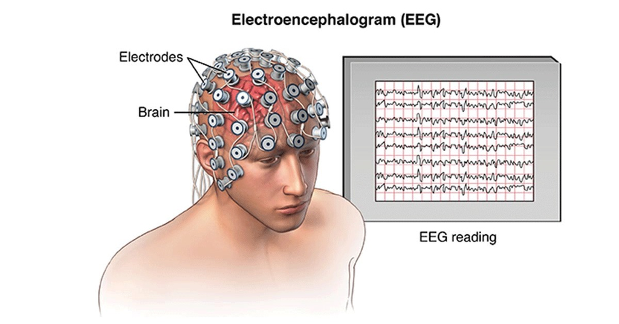

Figura 1: standard di rilevazione EEG

Il dato grezzo consiste dunque in una registrazione continua multicanale del potenziale elettrico in microVolts, dove ogni canale corrisponde ad un elettrodo presente sullo scalpo. Il formato standard delle registrazioni prevede due parametri fondamentali: il numero di canali e il sampling rate (misurato in Hz). Dai dati EEG possiamo dedurre varie informazioni quali l’ampiezza del segnale, la velocità di risposta del paziente (latenza) oppure la distribuzione topografica dell’attivazione nelle differenti aree corticali.

Se l’interesse è lo studio del tempo di risposta dell’attività corticale alla presentazione di uno stimolo, i dati in analisi sono di tipo ERPs (Event-Related Potentials).

Vista la forte rumorosità intrinseca di questi dati, si ha una prima fase di pre-elaborazione, seguita dalla fase di modellazione, nella quale possono venire considerati vari metodi quali, tra i più utilizzati: ANOVA per misure ripetute, MANOVA e modelli ad effetti misti.

Inoltre, nell’ambito psicometrico, un aspetto fondamentale è la gestione della molteplicità dei test svolti durante le analisi di questo tipo di dati.

Se venisse eseguito un singolo test, sarebbe facilmente gestibile la probabilità di produrre un falso positivo, che è infatti pari al livello alpha del test. Nel momento, però, in cui il numero dei test aumenta, la probabilità di eseguire almeno un rifiuto esplode, producendo, se non controllati, dei risultati poco affidabili perché contenenti un’alta percentuale di falsi positivi.

Per contrastare il problema dei test multipli, negli anni sono state proposte varie metodologie, tra le quali FamilyWise Error Rate (Frossard and Renaud 2022), comprendente le correzioni di Sidak (Midway et al. 2020), Bonferroni (Vialatte and Cichocki 2008) ed Holm (Durka et al. 2004), e False Discovery Rate (Verhoeven, Simonsen, and McIntyre 2005).

## 1.2 Metodologia lmEEG

Per modellare statisticamente i dati EEG lo standard attuale prevede l’utilizzo di modelli ad effetti casuali, soprattutto nel campo della psicologia comportamentale. Il motivo principale di questa scelta risiede nel fatto che questi modelli riescano a modellare contemporaneamente l’effetto incrociato fra soggetto e stimolo proposto al soggetto. Nella pratica però difficilmente vengono applicati vista la loro complessità computazionale, soprattutto se combinati con test di permutazione.

Nell’articolo (Visalli et al. 2024), viene proposta quindi una soluzione a questo problema, esponendo la metodologia lmeEEG, la quale permette di utilizzare un modello lineare con effetti misti nel caso di analisi univariata per dati EEG, superando però il limite computazionale e introducendo una soluzione maggiormente veloce.

La metodologia lmeEEG consiste nei seguenti passi:

1. Adattamento di un modello a effetti misti: per ogni canale e timepoint viene adattato un modello lineare ad effetti misti del tipo:

   $EEG_{ch,t} = X\beta + Zu + \epsilon$

   Dove X rappresenta la matrice degli effetti fissi e 𝛃 i coefficienti associati; Z è la matrice degli effetti casuali e u i coefficienti associati, infine $\epsilon$ è la componente residuale.
2. Si esegue una regressione lineare univariata sui dati EEG marginali: ai dati originali viene sottratta la componente casuale stimata

   $mEEG_{ch,t} = EEG - Zu = X\beta + \epsilon$

   Successivamente è possibile quindi adattare un semplice modello di regressione lineare multipla.
3. Infine viene eseguito un test di permutazione sui dati EEG marginalizzati, con l’obiettivo di riuscire a gestire l’errore di primo tipo.

In sintesi questa metodologia prevede l’adattamento di un modello lineare a effetti misti per ogni canale e timepoint, successivamente vengono sottratte le stime degli effetti casuali dai dati originali per poi adattare un modello lineare, infine su questi risultati viene applicato un test di permutazione per gestire la molteplicità.

## 1.3 Analisi esplorative

Il dataset *Dati_mixed_model* rappresenta un esperimento ERP dove viene rilevata l’attività cerebrale, tramite EEG, di 40 soggetti a cui vengono esposte quattro condizioni sperimentali visive differenti: un’immagine contenente un auto (Cars), una faccia (Faces) e il corrispettivo delle due in formato sfocato (ScrambledCars, ScrambledFaces). Per ogni soggetto sono stati rilevati i segnali di 28 canali, ciascuno riferito all’attività media nell’intervallo 160-180 ms trial-by-trial.

L’obiettivo di questa analisi è indagare se vi sia una differenza significativa tra i segnali cerebrali registrati nelle diverse condizioni sperimentali considerate a coppie: tra Cars e Faces e successivamente tra ScrambledCars e ScrambledFaces. Per condurre l’analisi viene implementata, utilizzando il software R la metodologia lmeEEG, presentata nell’articolo (Visalli et al. 2024).

```r
setwd("C:/Users/andre/Psicometria/PROGETTO")
library(dplyr)
library(readr)
library(tidyr)
# Estrazione del dataet --------------------------------------------------------
files <- list.files(path = "C:/Users/andre/Psicometria/PROGETTO",
                    pattern = "*_ERPsingletrials.txt")
dataset_list <- lapply(files, read_table)

# Unisci tutti i dataset
merged_dataset <- bind_rows(dataset_list)

# trasformo in fattori le variabili categoriali
merged_dataset <- merged_dataset %>%
  mutate(Condition = factor(Condition),
         ID = factor(ID),
         trial_idx = factor(trial_idx))
str(merged_dataset)
```

```
## tibble [10,920 × 31] (S3: tbl_df/tbl/data.frame)
##  $ FP1      : num [1:10920] -9.8 -6.03 -1.46 1.02 -5.35 ...
##  $ F3       : num [1:10920] -10.594 -0.993 -3.652 -5.36 -2.489 ...
##  $ F7       : num [1:10920] -11.749 -0.269 -10.908 -0.802 -6.602 ...
##  $ FC3      : num [1:10920] -11.4 1.75 -3.89 -3.71 -2.76 ...
##  $ C3       : num [1:10920] -6.72 2.9 -5.32 -4.38 -0.88 ...
##  $ C5       : num [1:10920] 1.21 4.46 -5.23 1.6 -5.89 ...
##  $ P3       : num [1:10920] 3.75 10.51 8.51 -6.81 4.87 ...
##  $ P7       : num [1:10920] 2.46 6.93 3.85 -5.15 -3.28 ...
##  $ PO7      : num [1:10920] 11.714 8.054 10.427 -0.965 -2.752 ...
##  $ PO3      : num [1:10920] 10.83 7.76 14.53 -8.19 10.69 ...
##  $ O1       : num [1:10920] 14.15 8.65 11.47 -1.68 4.93 ...
##  $ Oz       : num [1:10920] 14.17 -2.4 15.37 -1.37 -7.12 ...
##  $ Pz       : num [1:10920] 4.83 8.57 4.03 -8.36 12.35 ...
##  $ CPz      : num [1:10920] -1.35 5.2 1.02 -5.53 7.03 ...
```

[output cut: 17 more lines]

```r
#escludiamo gli NA
merged_dataset = merged_dataset[-which(is.na(merged_dataset$trial_idx)),]

# Trasformo in un dataset lungo
data_long = merged_dataset %>%
  pivot_longer(cols = -c(ID, Condition, trial_idx), names_to = "Elettrodi", values_to = "Segnale")
data_long <- data_long %>%
  mutate(Elettrodi = factor(Elettrodi))
```

Viene quindi condotta una analisi esplorativa enfatizzando la differenza tra le distribuzioni delle osservazioni tra le due coppie di condizioni. Da Figura 2 notiamo come le distribuzioni siano simili tra loro e con media pari a 0.

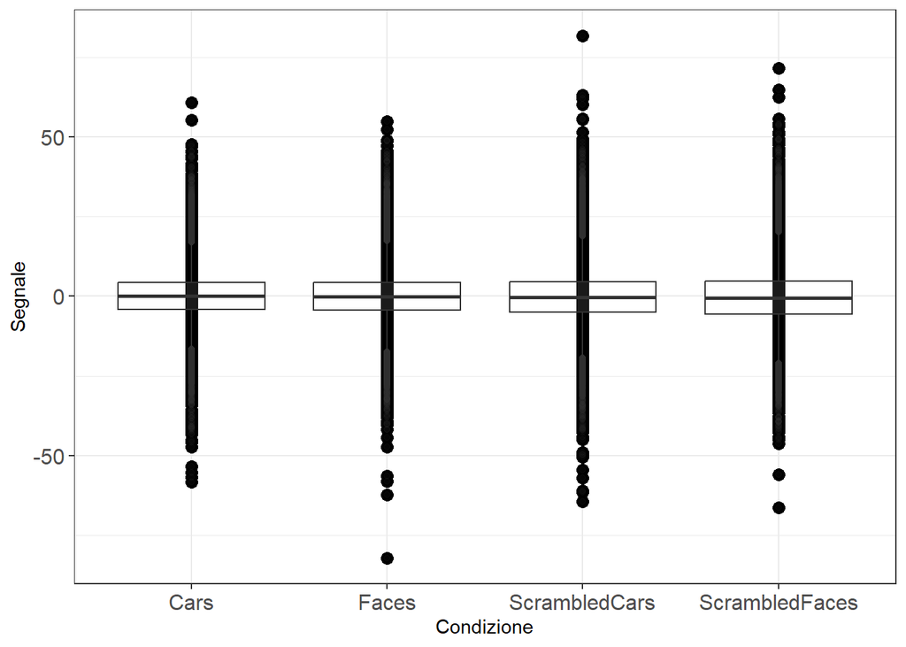

```r
library(ggplot2)
p <- ggplot(data_long,aes(Condition,Segnale))
p+geom_point(size = 3) +
  geom_boxplot(alpha=.1)+theme_bw() + labs(x = "Condizione", y = "Segnale") +
  theme(axis.text = element_text(size = 12))
```

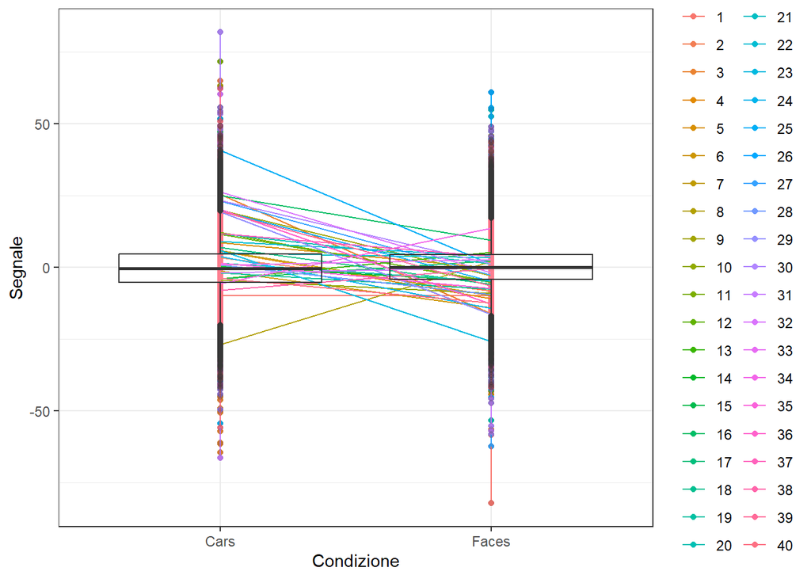

```r
p <- ggplot(data_long,aes(Condition == "Cars" | Condition == "Faces",Segnale))
p+geom_point(aes(group = ID, colour = ID))+
  geom_line(aes(group = ID, colour = ID))+
  geom_boxplot(alpha=.1)+theme_bw() + labs(x = "Condizione", y = "Segnale") +
  scale_x_discrete(label = c("Cars","Faces"))
```

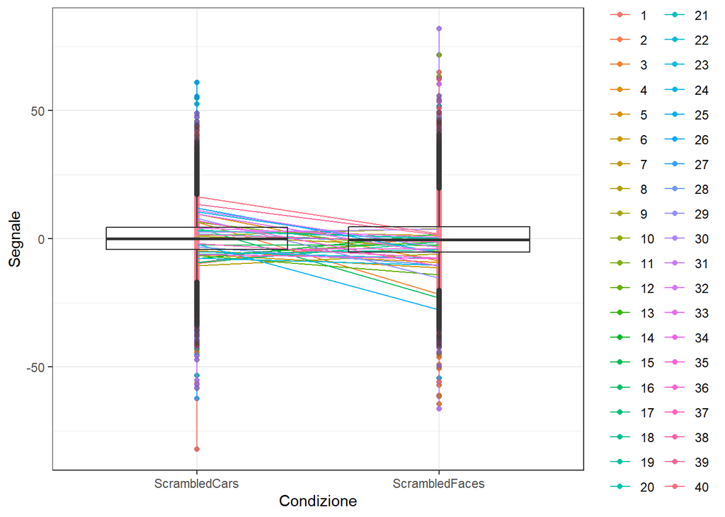

```r
p <- ggplot(data_long,aes(Condition == "ScrambledCars" | Condition == "ScrambledFaces",Segnale))
p+geom_point(aes(group = ID, colour = ID))+
  geom_line(aes(group = ID, colour = ID))+
  geom_boxplot(alpha=.1)+theme_bw() + labs(x = "Condizione", y = "Segnale") +
  scale_x_discrete(label = c("ScrambledCars","ScrambledFaces"))
```

Dalla figura 3 e 4 notiamo come vi sia un cambiamento sia tra le varie condizioni sperimentali, sia per ogni singolo soggetto, in particolare notiamo che in entrambi i casi dalla condizione Cars si ha una diminuzione verso valori della condizione Faces.

Se consideriamo i canali singolarmente si nota che c’è una lieve differenza tra i boxplot del segnale per le varie condizioni sperimentali. Si riportano in figura 5, 6, 7 i boxplot per il segnale sui canali P7, PO3, PO8.

```r
listaNomiElettrodi = levels(data_long$Elettrodi)
length(listaNomiElettrodi)
```

```
## [1] 28
```

```r
listaNomiElettrodi[22]
```

```
## [1] "P7"
```

```r
listaNomiElettrodi[24]
```

```
## [1] "PO3"
```

```r
listaNomiElettrodi[27]
```

```
## [1] "PO8"
```

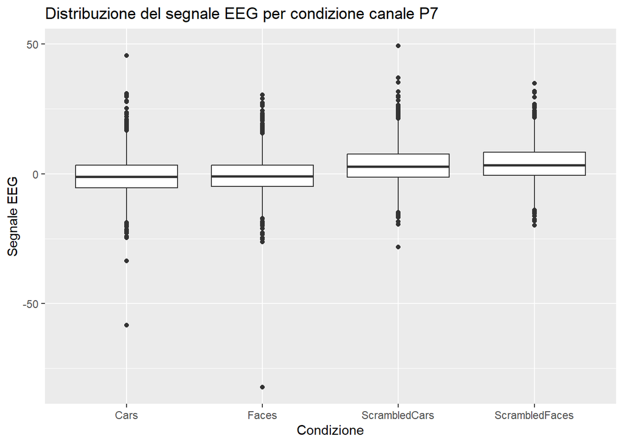

```r
ggplot(data_long
       %>% filter(Elettrodi == listaNomiElettrodi[22])
       , aes(x = Condition, y = Segnale)) +
  geom_boxplot() +
  labs(title = "Distribuzione del segnale EEG per condizione canale P7",
       x = "Condizione",
       y = "Segnale EEG")
```

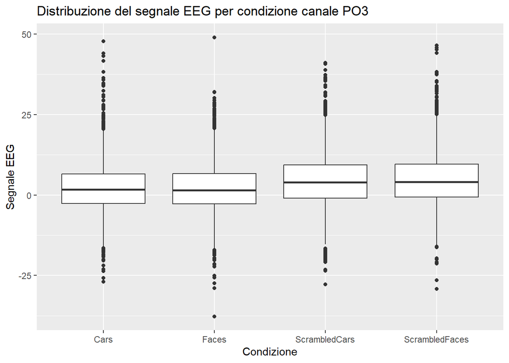

```r
ggplot(data_long
       %>% filter(Elettrodi == listaNomiElettrodi[24])
       , aes(x = Condition, y = Segnale)) +
  geom_boxplot() +
  labs(title = "Distribuzione del segnale EEG per condizione canale PO3",
       x = "Condizione",
       y = "Segnale EEG")
```

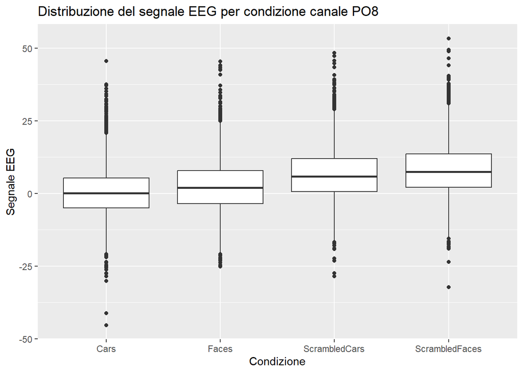

```r
ggplot(data_long
       %>% filter(Elettrodi == listaNomiElettrodi[27])
       , aes(x = Condition, y = Segnale)) +
  geom_boxplot() +
  labs(title = "Distribuzione del segnale EEG per condizione canale PO8",
       x = "Condizione",
       y = "Segnale EEG")
```

Nelle tabelle seguenti sono riportate le statistiche descrittive di sintesi del segnale riferito ai tre canali selezionati per le diverse condizioni sperimentali: le medie dei segnali, soprattutto per quanto riguarda le condizioni Faces e Cars nel canale PO8, sono diverse.

```r
# summary per ciascuna condizione per il canale p7
df = data_long %>%
  filter(Elettrodi %in% c("P7"))

df %>%
  group_by(Condition) %>%
  summarise(
    mean_signal = mean(Segnale, na.rm = TRUE),
    sd_signal = sd(Segnale, na.rm = TRUE),
    min_signal = min(Segnale, na.rm = TRUE),
    max_signal = max(Segnale, na.rm = TRUE),
    n = n()
  )
```

```
## # A tibble: 4 × 6
##   Condition      mean_signal sd_signal min_signal max_signal     n
##   <fct>                <dbl>     <dbl>      <dbl>      <dbl> <int>
## 1 Cars                -0.995      7.04      -58.3       45.5  2724
## 2 Faces               -0.687      7.05      -82.2       30.4  2760
## 3 ScrambledCars        3.34       6.96      -28.3       49.4  2729
## 4 ScrambledFaces       3.90       6.83      -19.9       35.0  2705
```

```r
# summary per ciascuna condizione per il canale p03
df = data_long %>%
  filter(Elettrodi %in% c("PO3"))

df %>%
  group_by(Condition) %>%
  summarise(
    mean_signal = mean(Segnale, na.rm = TRUE),
    sd_signal = sd(Segnale, na.rm = TRUE),
    min_signal = min(Segnale, na.rm = TRUE),
    max_signal = max(Segnale, na.rm = TRUE),
    n = n()
  )
```

```
## # A tibble: 4 × 6
##   Condition      mean_signal sd_signal min_signal max_signal     n
##   <fct>                <dbl>     <dbl>      <dbl>      <dbl> <int>
## 1 Cars                  2.24      7.84      -27.0       47.8  2724
## 2 Faces                 2.22      8.02      -37.7       49.0  2760
## 3 ScrambledCars         4.61      8.47      -27.7       41.0  2729
## 4 ScrambledFaces        4.95      8.53      -29.1       46.5  2705
```

```r
# summary per ciascuna condizione per il canale po8
df = data_long %>%
  filter(Elettrodi %in% c("PO8"))

df %>%
  group_by(Condition) %>%
  summarise(
    mean_signal = mean(Segnale, na.rm = TRUE),
    sd_signal = sd(Segnale, na.rm = TRUE),
    min_signal = min(Segnale, na.rm = TRUE),
    max_signal = max(Segnale, na.rm = TRUE),
    n = n()
  )
```

```
## # A tibble: 4 × 6
##   Condition      mean_signal sd_signal min_signal max_signal     n
##   <fct>                <dbl>     <dbl>      <dbl>      <dbl> <int>
## 1 Cars                 0.463      9.06      -45.3       45.5  2724
## 2 Faces                2.46       9.54      -25.2       45.5  2760
## 3 ScrambledCars        6.75       9.01      -28.5       48.3  2729
## 4 ScrambledFaces       8.24       9.53      -32.2       53.4  2705
```

# 2 Analisi

Procedendo con l’analisi, sono stati adattati diversi modelli, dal modello lineare semplice fino a vari modelli a effetti misti. Ogni canale è stato considerato singolarmente, ottenendo così 28 modelli distinti, uno per ciascun canale.

Di seguito, si presenta il codice e i risultati dei modelli adattati solo per il canale PO8, ma il procedimento è analogo per gli altri canali.

```r
# canale PO8
df = data_long %>%
  filter(Condition %in% c("Faces","Cars")) %>%
  filter(Elettrodi == "PO8")

library(lmerTest)
library(lme4)
library(lmtest)
```

Il primo modello considerato è il modello lineare semplice (*m0*) , che esamina la variabile risposta in funzione della variabile indicatrice per la condizione sperimentale. Sebbene questa variabile abbia un effetto significativo (come indicato nel summary), il modello non mostra un buon adattamento complessivo. Questo è dovuto al fatto che non si considerano né gli effetti individuali dei soggetti né la variabilità tra le immagini utilizzate nell’esperimento.

```r
# modello lineare semplice
m0 = lm(Segnale ~ Condition, data = df)
summary(m0)
```

```
##
## Call:
## lm(formula = Segnale ~ Condition, data = df)
##
## Residuals:
##     Min      1Q  Median      3Q     Max
## -45.745  -5.717  -0.411   5.127  45.056
##
## Coefficients:
##                Estimate Std. Error t value Pr(>|t|)
## (Intercept)      0.4633     0.1783   2.598  0.00939 **
## ConditionFaces   1.9989     0.2513   7.953 2.19e-15 ***
## ---
## Signif. codes:  0 '***' 0.001 '**' 0.01 '*' 0.05 '.' 0.1 ' ' 1
##
## Residual standard error: 9.306 on 5482 degrees of freedom
## Multiple R-squared:  0.01141,    Adjusted R-squared:  0.01123
## F-statistic: 63.25 on 1 and 5482 DF,  p-value: 2.193e-15
```

Il secondo modello (*m1*) è del tipo
$$Y_{ij}=\beta_{0} +
\beta_{1}⋅Condition+β_{j}+ϵ_{ij} ,
con j=1,...,n$$
Si tratta di un modello a effetti misti che include un’intercetta casuale per ogni soggetto. In questo caso, sia l’effetto del soggetto sia la condizione sperimentale risultano significativi.

```r
# modello con effetto casuale per soggetto
m1=lmer(Segnale ~ Condition + (1|ID),data=df)
summary(m1)
```

```
## Linear mixed model fit by REML. t-tests use Satterthwaite's method [
## lmerModLmerTest]
## Formula: Segnale ~ Condition + (1 | ID)
##    Data: df
##
## REML criterion at convergence: 38247.1
##
## Scaled residuals:
##     Min      1Q  Median      3Q     Max
## -5.9328 -0.5884 -0.0219  0.5596  5.5501
##
## Random effects:
##  Groups   Name        Variance Std.Dev.
##  ID       (Intercept) 25.43    5.043
##  Residual             60.78    7.796
## Number of obs: 5484, groups:  ID, 40
##
## Fixed effects:
##                 Estimate Std. Error        df t value Pr(>|t|)
## (Intercept)       0.4863     0.8114   40.4273   0.599    0.552
## ConditionFaces    2.1868     0.2121 5447.5564  10.309   <2e-16 ***
## ---
## Signif. codes:  0 '***' 0.001 '**' 0.01 '*' 0.05 '.' 0.1 ' ' 1
##
## Correlation of Fixed Effects:
##             (Intr)
## ConditinFcs -0.131
```

Il terzo modello (*m2*) è
$$Y_{ijk}
= \beta_0 + \beta_1 \cdot \text{Condition} +
\beta_{j}+\gamma_{k}ϵ_{ijk}$$
con j=1,…,n, k=1,…, e i = 1,…,n.

Questo modello considera un’intercetta casuale per il soggetto e un’intercetta casuale per l’identificativo dell’immagine. In questo caso, l’effetto dell’immagine non sembra apportare miglioramenti significativi al modello, mentre rimangono rilevanti gli effetti del soggetto e della condizione sperimentale.

```r
# modello con effetto casuale per soggetto e per immagine
m2 = lmer(Segnale ~ Condition +(1|ID)+ (1|trial_idx), data = df)
summary(m2)
```

```
## Linear mixed model fit by REML. t-tests use Satterthwaite's method [
## lmerModLmerTest]
## Formula: Segnale ~ Condition + (1 | ID) + (1 | trial_idx)
##    Data: df
##
## REML criterion at convergence: 38242.5
##
## Scaled residuals:
##     Min      1Q  Median      3Q     Max
## -5.9407 -0.5897 -0.0236  0.5643  5.5483
##
## Random effects:
##  Groups    Name        Variance Std.Dev.
##  trial_idx (Intercept)  0.3429  0.5855
##  ID        (Intercept) 25.4322  5.0430
##  Residual              60.4411  7.7744
## Number of obs: 5484, groups:  trial_idx, 80; ID, 40
##
## Fixed effects:
##                Estimate Std. Error      df t value Pr(>|t|)
## (Intercept)      0.4860     0.8166 41.4354   0.595    0.555
## ConditionFaces   2.1892     0.2488 80.3359   8.798 2.12e-13 ***
## ---
## Signif. codes:  0 '***' 0.001 '**' 0.01 '*' 0.05 '.' 0.1 ' ' 1
##
## Correlation of Fixed Effects:
##             (Intr)
## ConditinFcs -0.152
```

Il quarto modello (*m3*)
$$Y_{ijk}=
\beta_{0}+\beta_{1}⋅Condition+γ_{j}+γ_{1j}⋅Condition+γ_{2k}+ϵ_{ijk}$$
con j=1,…,n e k=1,…,n i = 1,…,n.

Questo modello considera un’intercetta casuale per il soggetto, un’intercetta casuale per l’identificativo dell’immagine e un effetto casuale per l’interazione tra soggetto e condizione sperimentale. Questo è il modello utilizzato per le successive analisi.

```r
# modello con effetto casuale per soggetto e per immagine e effetto casuale per interazione
# tra condizione sperimentale e id del soggetto
m3 = lmer(Segnale ~ Condition + (1 + Condition|ID) + (1|trial_idx) , data = df)
summary(m3)
```

```
## Linear mixed model fit by REML. t-tests use Satterthwaite's method [
## lmerModLmerTest]
## Formula: Segnale ~ Condition + (1 + Condition | ID) + (1 | trial_idx)
##    Data: df
##
## REML criterion at convergence: 37867.5
##
## Scaled residuals:
##     Min      1Q  Median      3Q     Max
## -6.6240 -0.5917 -0.0140  0.5613  5.9501
##
## Random effects:
##  Groups    Name           Variance Std.Dev. Corr
##  trial_idx (Intercept)     0.4236  0.6509
##  ID        (Intercept)    24.2141  4.9208
##            ConditionFaces 20.5751  4.5360   -0.19
##  Residual                 55.3465  7.4395
## Number of obs: 5484, groups:  trial_idx, 80; ID, 40
##
## Fixed effects:
##                Estimate Std. Error      df t value Pr(>|t|)
## (Intercept)      0.5076     0.7979 40.3673   0.636   0.5282
## ConditionFaces   2.0231     0.7640 41.1673   2.648   0.0114 *
## ---
## Signif. codes:  0 '***' 0.001 '**' 0.01 '*' 0.05 '.' 0.1 ' ' 1
##
## Correlation of Fixed Effects:
##             (Intr)
## ConditinFcs -0.226
```

Per ogni canale, utilizzando il modello *m3*, sono state ottenute le stime degli effetti casuali seguendo le indicazioni dell’articolo (Visalli et al. 2024). Sottraendo questi effetti casuali dal segnale originario, si è ottenuta una nuova variabile risposta (*y_new*) che dovrebbe idealmente permettere la scambiabilità per i test di permutazione. Tuttavia, le stime ottenute non si sono rivelate utili, rendendo i risultati insoddisfacenti.

```r
# stima degli effetti casuali
library(flip)
eff = ranef(m3)
gamma_id = eff$ID[,1]
gamma_id_F = eff$ID[,2]
gamma_img = eff$trial_idx
rownames(gamma_img)
```

```
##  [1] "1"  "2"  "3"  "4"  "5"  "6"  "7"  "8"  "9"  "10" "11" "12" "13" "14" "15"
## [16] "16" "17" "18" "19" "20" "21" "22" "23" "24" "25" "26" "27" "28" "29" "30"
## [31] "31" "32" "33" "34" "35" "36" "37" "38" "39" "40" "41" "42" "43" "44" "45"
## [46] "46" "47" "48" "49" "50" "51" "52" "53" "54" "55" "56" "57" "58" "59" "60"
## [61] "61" "62" "63" "64" "65" "66" "67" "68" "69" "70" "71" "72" "73" "74" "75"
## [76] "76" "77" "78" "79" "80"
```

```r
df_2 = df %>% mutate(eff_id = NA, eff_idc = NA, eff_img = NA)

for(i in 1:NROW(df_2)){
  df_2[i,]$eff_id = gamma_id[as.numeric(df_2[i,]$ID)]
}

for(i in 1:NROW(df_2)){
  df_2[i,]$eff_idc = ifelse(df_2[i,]$Condition == "Faces", gamma_id_F[as.numeric(df_2[i,]$ID)], 0)
}

for(i in 1:NROW(df_2)){
  df_2[i,]$eff_img = gamma_img[rownames(gamma_img) == df_2[i,]$trial_idx,1]
}

# creo la y_new togliendo gli effetti casuali stimati
df_2 <- df_2 %>% mutate(y_new = Segnale-eff_id-eff_idc-eff_img)

# modello lineare con la nuova y come var risposta:
modello_lin = lm(y_new~Condition, data = df_2)
summary(modello_lin)
```

```
##
## Call:
## lm(formula = y_new ~ Condition, data = df_2)
##
## Residuals:
##     Min      1Q  Median      3Q     Max
## -49.280  -4.402  -0.104   4.176  44.266
##
## Coefficients:
##                Estimate Std. Error t value Pr(>|t|)
## (Intercept)      0.5076     0.1412   3.595 0.000328 ***
## ConditionFaces   2.0231     0.1991  10.163  < 2e-16 ***
## ---
## Signif. codes:  0 '***' 0.001 '**' 0.01 '*' 0.05 '.' 0.1 ' ' 1
##
## Residual standard error: 7.371 on 5482 degrees of freedom
## Multiple R-squared:  0.01849,    Adjusted R-squared:  0.01831
## F-statistic: 103.3 on 1 and 5482 DF,  p-value: < 2.2e-16
```

Nonostante ciò, i test di permutazione sono stati comunque effettuati ottenendo i risultati riportati di seguito.

I test di permutazione sono utilizzati per verificare l’effettiva relazione tra la variabile esplicativa e le variabili risposta nel caso in cui si hanno dati funzionali: la statistica in questo caso non dà modo di derivare una distribuzione teorica nulla sulla quale verificare le ipotesi.

Il test di permutazione si basa sull’assunzione che, se non vi fosse una relazione effettiva tra la variabile risposta e le covariate, non vi dovrebbe essere differenza se questo fosse ricalcolato associando in modo casuale le stesse. Basandosi su questa ipotesi, risulta abbastanza semplice creare una distribuzione nulla empirica, questa sarà ottenuta permutando la variabile risposta senza però modificare le esplicative, e di volta in volta ristimando il modello. Successivamente sarà quindi possibile ricalcolare il test ed avere una distribuzione nulla dello stesso. Andando a confrontare il valore ottenuto con la distribuzione, sarà perciò visibile quanto il risultato ottenuto è distante dall’ipotesi nulla. Il calcolo del valore p si effettua semplicemente contando la proporzione di valori permutati che si trovano più distanti dal valore del test calcolato.

```r
# test di permutazione
test <- flip(df_2$y_new ~ df_2$Condition)
test@res$`p-value`
```

```
## [1] 0.001
```

## 2.1 Simulazioni

Per dimostrare che gli effetti casuali stimati dai modelli non corrispondono ai veri effetti casuali, si presentano diverse simulazioni. Queste simulazioni mostrano che l’utilizzo delle stime dei modelli a effetti casuali non produce risultati statistici ragionevoli. In particolare, si osserva che l’errore di I tipo non è sotto controllo e che le stime degli effetti casuali sono distanti dai veri valori degli effetti casuali.

La procedura prevede che venga generato un dataframe con le seguenti variabili:

- Un vettore di ID riferiti al soggetto.
- Un vettore di valori +/-1 a rappresenatre la condizione sperimentale (Cars vs Faces).
- Un vettore di ID riferite all’immagine sottoposta al soggetto.

Ad ogni replicazione, viene generato il segnale, che è la variabile risposta, per ciascuna delle condizioni sperimentali. Il segnale generato è composto da:

- Un errore casuale (valore casuale generato da una $N(0,1)$).
- Un effetto dell’ID dell’immagine (valore casuale generato da una $N(0,1)$).
- Un effetto dell’ID del soggetto (valore casuale generato da una $N(0,1)$)).
- Un effetto casuale del soggetto data la condizione sperimentale (valore casuale generato da una $N(0,1)$).

Sui dati simulati vengono adattati diversi modelli:

- **Modello reff2 (modello corretto)**: modello a effetti misti che considera un’intercetta casuale per il soggetto, un’intercetta casuale per l’ID dell’immagine e un effetto casuale per l’interazione tra soggetto e condizione sperimentale.
- **Modello reff1**: modello a effetti misti che considera un’intercetta casuale per il soggetto e un effetto casuale per l’interazione tra soggetto e condizione sperimentale.
- **Summary Statistics:** approccio che riassume la variabile risposta come singole statistiche riassuntive per ogni singolo soggetto.
- **Modello mod_mio (proposto nell’articolo):** modello che, a partire dal modello reff2, sottrae gli effetti casuali stimati e, ottenuta così la nuova variabile risposta, esegue i test di permutazione.

Vengono messi in evidenza i p-value dei diversi modelli stimati e viene mostrata la funzione di ripartizione empirica per verificare la compatibilità con la distribuzione teorica dei p-value (U(0,1)).

## 2.2 Simulazioni eseguite

1. **Prima Simulazione**:
   - **Parametri**: 50 soggetti, 10 stimoli (ID dell’immagine) per soggetto, 100 replicazioni.
   - **Risultati**: Il modello che non considera l’intercetta casuale per l’immagine (*reff1*) da risultati peggiori (non controlla l’errore di I tipo), così come la summary statistic. Il modello corretto (*reff2*) controlla l’errore di I tipo come previsto, mentre il modello *mod_mio* è il modello che produce i risultati peggiori.

     ```r
     library(devtools)
     library(lmerTest)
     N=50 # numero soggetti
     ns=rep(10,N) # numero stimoli (per soggetto)

     Stim=rep(1:ns[1],N)
     Subj=rep(1:N,ns)
     Nn=length(Stim)
     X=rep(c(1,-1),length.out=Nn)

     #disegno sperimentale
     D=data.frame(X=X,Subj=Subj,Stim=Stim)
     contrast_mat= t(sapply(unique(Subj), function(sb) Subj==sb)*1)

     #Il nostro modello
     modello_mio = function(D){
       tmp = lmer(y ~ X + (1 + X|Subj) + (1|Stim) , data = D)
       new_sig <- model.matrix(tmp) %*% as.numeric(summary(tmp)$coef[1:2,1]) + residuals(tmp)
       test <- flip(new_sig, D$X)
       test@res$`p-value`
     }
     # genero dati con random effect per soggetto e stimolo
     # e stimo con il modello corretto (reff2) e il modello
     # che usa solo i soggetti come random effect
     res=t(replicate(100,{
       Rsubj_int=rep(rnorm(N),ns)
       Rsubj_slop=rep(rnorm(N),ns)
       Rstim=rep(rnorm(ns[1]),N)
       D$y=rnorm(Nn)+Rstim+Rsubj_slop*X+Rsubj_int
       mod_mio = modello_mio(D)
       mod=lmer(y~X+(1+X|Subj)+(1|Stim),data=D)
       modN=lmer(y~X+(1+X|Subj),data=D)
       summary_stat=contrast_mat%*%D$y
       c(reff1=summary(modN)$coeff[2,5],
         summary_stat=t.test(summary_stat)$p.val,
         reff2=summary(mod)$coeff[2,5],
         nuovo = mod_mio)
     }))
     ```

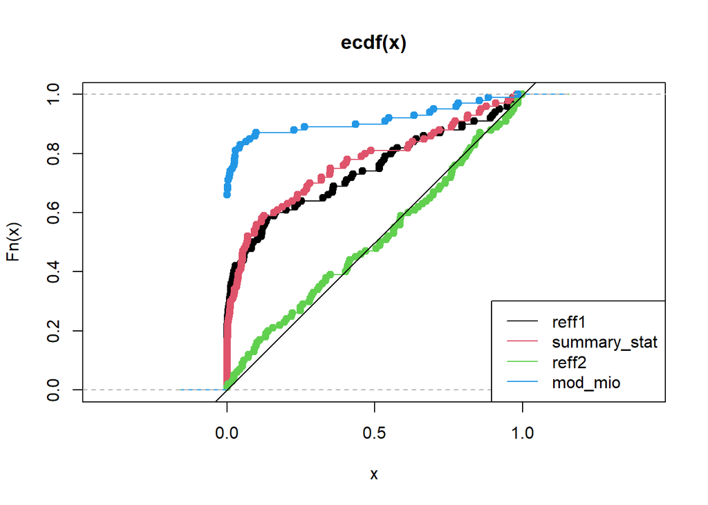

     ```r
     # risultati:
     plot.ecdf(res[,1],asp=1)
     plot.ecdf(res[,2],col=2,add=TRUE)
     plot.ecdf(res[,3],col=3,add=TRUE)
     plot.ecdf(res[,4],col=4,add=TRUE)
     legend("bottomright", lty = c(1,1,1,1), c('reff1', "summary_stat", "reff2", "mod_mio"), col = 1:4)
     abline(0,1)
     ```

     ```r
     r41sqrt10::summaryResSim(res)
     ```

     ```
     ##                    <=0.01      <=0.05 <=0.1 <=0.5    <=0.75
     ## LowerLim     -0.009899749 0.006411011  0.04  0.40 0.6633975
     ## UpperLim      0.029899749 0.093588989  0.16  0.60 0.8366025
     ## reff1         0.300000000 0.430000000  0.50  0.74 0.8800000
     ## summary_stat  0.260000000 0.430000000  0.55  0.81 0.8800000
     ## reff2         0.020000000 0.070000000  0.15  0.47 0.7100000
     ## nuovo         0.730000000 0.830000000  0.87  0.90 0.9500000
     ```

2. **Seconda Simulazione**:
   - **Parametri**: 50 soggetti, 10 stimoli (ID dell’immagine) per soggetto, 100 replicazioni.
   - **Modifiche**: Al posto di togliere gli effetti stimati, vengono tolti gli effetti veri nel modello *mod_mio*.
   - **Risultati**: L’errore di I tipo è sotto controllo, suggerendo che il problema riscontrato nella prima simulazione sia dovuto a una stima errata degli effetti casuali.

     ```r
     N=50 # numero soggetti
     ns=rep(10,N) # numero stimoli (per soggetto)

     Stim=rep(1:ns[1],N)
     Subj=rep(1:N,ns)
     Nn=length(Stim)
     X=rep(c(1,-1),length.out=Nn)

     #disegno sperimentale
     D=data.frame(X=X,Subj=Subj,Stim=Stim)
     contrast_mat= t(sapply(unique(Subj), function(sb) Subj==sb)*1)

     modello_mio1 = function(D, eff_veri){
       tmp = lmer(y ~ X + (1 + X|Subj) + (1|Stim) , data = D)
       # permutazione
       new_sig <- D$y - eff_veri
       test <- flip(new_sig, D$X)
       test@res$`p-value`
     }

     # genero dati con random effect per soggetto e stimolo
     # e stimo con il modello corretto (reff2) e il modello
     # che usa solo i soggetti come random effect
     res=t(replicate(100,{
       Rsubj_int=rep(rnorm(N),ns)
       Rsubj_slop=rep(rnorm(N),ns)
       Rstim=rep(rnorm(ns[1]),N)
       eff = Rstim+Rsubj_slop*X+Rsubj_int
       D$y=rnorm(Nn)+Rstim+Rsubj_slop*X+Rsubj_int
       mod_mio = modello_mio1(D,eff)
       mod=lmer(y~X+(1+X|Subj)+(1|Stim),data=D)
       modN=lmer(y~X+(1+X|Subj),data=D)
       summary_stat=contrast_mat%*%D$y
       c(reff1=summary(modN)$coeff[2,5],
         summary_stat=t.test(summary_stat)$p.val,
         reff2=summary(mod)$coeff[2,5],
         nuovo = mod_mio)
     }))
     ```

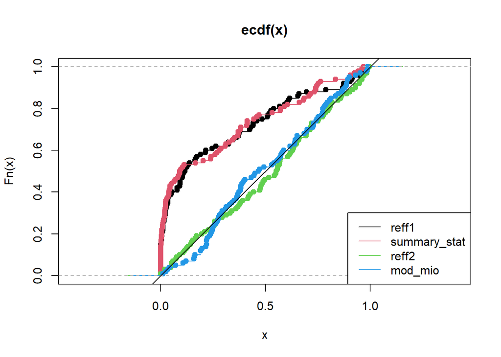

     ```r
     # risultati:
     plot.ecdf(res[,1],asp=1)
     plot.ecdf(res[,2],col=2,add=TRUE)
     plot.ecdf(res[,3],col=3,add=TRUE)
     plot.ecdf(res[,4],col=4,add=TRUE)
     legend("bottomright", lty = c(1,1,1,1), c('reff1', "summary_stat", "reff2", "mod_mio"), col = 1:4)
     abline(0,1)
     ```

     ```r
     r41sqrt10::summaryResSim(res)
     ```

     ```
     ##                    <=0.01      <=0.05 <=0.1 <=0.5    <=0.75
     ## LowerLim     -0.009899749 0.006411011  0.04  0.40 0.6633975
     ## UpperLim      0.029899749 0.093588989  0.16  0.60 0.8366025
     ## reff1         0.230000000 0.390000000  0.46  0.75 0.8800000
     ## summary_stat  0.250000000 0.430000000  0.51  0.77 0.9100000
     ## reff2         0.010000000 0.040000000  0.10  0.46 0.7300000
     ## nuovo         0.000000000 0.040000000  0.05  0.52 0.7500000
     ```

3. **Terza Simulazione**:
   - **Parametri**: 10 soggetti, 10 stimoli (ID Immagine), ogni immagine ripetuta 10 volte, 100 replicazioni.
   - **Risultati**: Anche ripetendo il test con 10 soggetti e 10 stimoli, i risultati non mostrano miglioramenti rispetto alla prima simulazione.

     ```r
     N1 = 10 # numero soggetti
     ns1 = rep(10, N1*10) # numero stimoli

     Stim=rep(1:ns[1],N)
     Subj=rep(1:N,ns)
     Nn=length(Stim)
     X=rep(c(1,1,1,1,1,1,1,1,1,1,-1,-1,-1,-1,-1,-1,-1,-1,-1,-1),length.out=1000)

     D1 = data.frame(X=X)
     D1$Stim = rep(c(rep(1,10),rep(2,10),rep(3,10),rep(4,10),rep(5,10),
                     rep(6,10),rep(7,10),rep(8,10),rep(9,10),rep(10,10)),10)
     D1$Subj = c(rep(1,100),rep(2,100),rep(3,100),rep(4,100),rep(5,100),
                 rep(6,100),rep(7,100),rep(8,100),rep(9,100),rep(10,100))
     contrast_mat1= t(sapply(unique(Subj), function(sb) Subj==sb)*1)

     res1=t(replicate(100,{
       Rsubj_int=rep(rnorm(100),ns1)
       Rsubj_slop=rep(rnorm(100),ns1)
       Rstim=rep(c(replicate(10,rep(rnorm(1),10))),10)
       D1$y=rnorm(1000)+Rstim+Rsubj_slop*X+Rsubj_int
       mod=lmer(y~X+(1+X|Subj)+(1|Stim),data=D1)
       modN=lmer(y~X+(1+X|Subj),data=D1)
       summary_stat=rep(0,10)
       for(i in 1:length(summary_stat)){
       summary_stat[i] = mean(D1[D1$Subj==i,]$y)
       }
       c(reff1=summary(modN)$coeff[2,5],
         summary_stat=t.test(summary_stat)$p.val,
         reff2=summary(mod)$coeff[2,5],
         nuovo = modello_mio(D1))
     }))
     ```

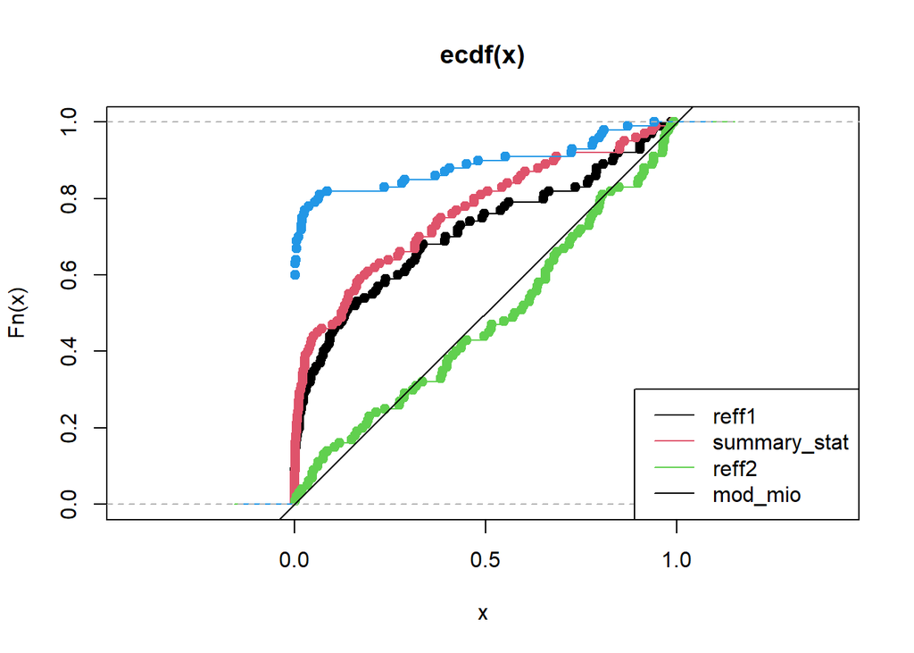

     ```r
     # risultati:
     plot.ecdf(res1[,1],asp=1)
     plot.ecdf(res1[,2],col=2,add=TRUE)
     plot.ecdf(res1[,3],col=3,add=TRUE)
     plot.ecdf(res1[,4],col=4,add=TRUE)
     legend("bottomright", lty = c(1,1,1,1), c('reff1',"summary_stat", "reff2", "mod_mio"), col = 1:3)
     abline(0,1)
     ```

     ```r
     r41sqrt10::summaryResSim(res1)
     ```

     ```
     ##                    <=0.01      <=0.05 <=0.1 <=0.5    <=0.75
     ## LowerLim     -0.009899749 0.006411011  0.04  0.40 0.6633975
     ## UpperLim      0.029899749 0.093588989  0.16  0.60 0.8366025
     ## reff1         0.190000000 0.340000000  0.45  0.76 0.8300000
     ## summary_stat  0.240000000 0.440000000  0.47  0.81 0.9200000
     ## reff2         0.020000000 0.090000000  0.14  0.44 0.7200000
     ## nuovo         0.690000000 0.780000000  0.82  0.90 0.9300000
     ```

4. **Quarta Simulazione**:
   - **Parametri**: Utilizzo delle numerosità del dataset originale (40 soggetti, 80 stimoli), 100 replicazioni.
   - **Risultati**: Anche con le numerosità dei dati originali, il modello *mod_mio* non riesce a controllare l’errore di I tipo.

     ```r
     # Creiamo un nuovo dataset con dimensione dei dati reali
     # 40 soggetti, 2 condizioni, 80 immagini
     D2 = data.frame(Subj = df$ID)
     D2$X = ifelse(df$Condition=="Faces",1,-1)
     D2$Stim = df$trial_idx
     D2$y = rep(0,nrow(D2))

     res2=t(replicate(100,{
       Rsubj_int=rep(rnorm(1),40)
       RsubjX_slop1=rnorm(40)
       RsubjX_slop0=rep(rnorm(1),40)
       Rstim=c(rnorm(40), rep(0,60), rnorm(40))
       for(i in 1:nrow(D2)){
         D2$y[i]=rnorm(1)+
           Rsubj_int[D2$Subj[i]] +
           RsubjX_slop1[D2$Subj[i]]*D2$X[i] +
           Rstim[D2$Stim[i]]
       }
       mod=lmer(y~X+(1+X|Subj)+(1|Stim),data=D2)
       modN=lmer(y~X+(1+X|Subj),data=D2)
       summary_stat=rep(0,80)
       for(i in 1:length(summary_stat)){
          summary_stat[i] = mean(D2[D2$Subj==i,]$y)
       }
       c(reff1=summary(modN)$coeff[2,5],
         summary_stat=t.test(summary_stat)$p.val,
         reff2=summary(mod)$coeff[2,5],
         nuovo = modello_mio(D2))
     }))
     ```

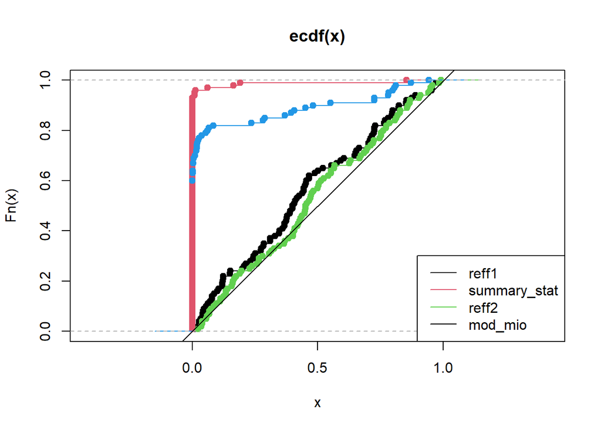

     ```r
     #risultati:
     plot.ecdf(res2[,1],asp=1)
     plot.ecdf(res2[,2],col=2,add=TRUE)
     plot.ecdf(res2[,3],col=3,add=TRUE)
     plot.ecdf(res1[,4],col=4,add=TRUE)
     legend("bottomright", lty = c(1,1,1,1), c('reff1',"summary_stat", "reff2", "mod_mio"), col = 1:3)
     abline(0,1)
     ```

     ```r
     r41sqrt10::summaryResSim(res2)
     ```

     ```
     ##                    <=0.01      <=0.05 <=0.1 <=0.5    <=0.75
     ## LowerLim     -0.009899749 0.006411011  0.04  0.40 0.6633975
     ## UpperLim      0.029899749 0.093588989  0.16  0.60 0.8366025
     ## reff1         0.010000000 0.090000000  0.16  0.63 0.8200000
     ## summary_stat  0.940000000 0.960000000  0.97  0.99 0.9900000
     ## reff2         0.000000000 0.040000000  0.11  0.57 0.7700000
     ## nuovo         0.880000000 0.900000000  0.91  0.96 0.9800000
     ```

Sono state provate le medesime simulazioni variando sia la numerosità che il numero di replicazioni, ottenendo risultati comparabili a quelli riportati. Per semplicità sono state riportate le simulazioni maggiormente rilevanti.

# 3 Conclusioni

Le simulazioni evidenziano che il modello *mod_mio* non riesce a controllare l’errore di I tipo, contrariamente al modello corretto (*reff2*). La rimozione degli effetti stimati sembra essere la causa principale dei pessimi risultati del modello *mod_mio*. Per controllare correttamente l’errore di I tipo, è fondamentale utilizzare modelli che stimino accuratamente gli effetti casuali.

Alla luce di questi risultati, si è deciso di non procedere con l’analisi nel caso multivariato né di procedere con l’analisi con il confronto tra le altre due condizioni sperimentali prese in analisi (scrambled cars vs scrambled faces).

# Bibliografia

Durka, P. J., J. Zygierewicz, H. Klekowicz, J. Ginter, and K. J. Blinowska. 2004. “On the Statistical Significance of Event-Related EEG Desynchronization and Synchronization in the Time-Frequency Plane.” *IEEE Transactions on Biomedical Engineering* 51 (7): 1167–75. https://doi.org/10.1109/tbme.2004.827341.

Frossard, Jaromil, and Olivier Renaud. 2022. “The Cluster Depth Tests: Toward Point-Wise Strong Control of the Family-Wise Error Rate in Massively Univariate Tests with Application to M/EEG.” *NeuroImage* 247 (February): 118824. https://doi.org/10.1016/j.neuroimage.2021.118824.

Midway, Stephen, Matthew Robertson, Shane Flinn, and Michael Kaller. 2020. “Comparing Multiple Comparisons: Practical Guidance for Choosing the Best Multiple Comparisons Test.” *PeerJ* 8 (December): e10387. https://doi.org/10.7717/peerj.10387.

Verhoeven, Koen J. F., Katy L. Simonsen, and Lauren M. McIntyre. 2005. “Implementing False Discovery Rate Control: Increasing Your Power.” *Oikos* 108 (3): 643–47. https://doi.org/10.1111/j.0030-1299.2005.13727.x.

Vialatte, Francois-Benoit, and Andrzej Cichocki. 2008. “Split-Test Bonferroni Correction for QEEG Statistical Maps.” *Biological Cybernetics* 98 (4): 295–303. https://doi.org/10.1007/s00422-008-0210-8.

Visalli, Antonino, Maria Montefinese, Giada Viviani, Livio Finos, Antonino Vallesi, and Ettore Ambrosini. 2024. “lmeEEG: Mass Linear Mixed-Effects Modeling of EEG Data with Crossed Random Effects.” *Journal of Neuroscience Methods* 401 (January): 109991. https://doi.org/10.1016/j.jneumeth.2023.109991.